# Variables Aleatorias

Edimer David Jaramillo

17 de abril de 2018

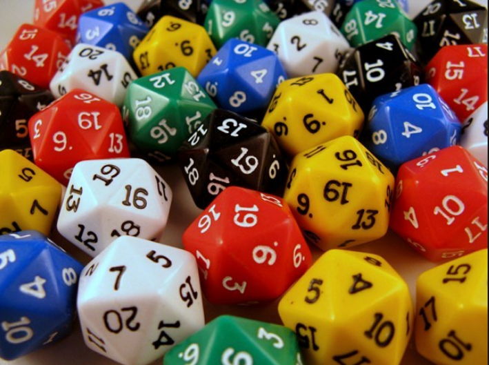

# Variable aleatoria: concepto

Una variable aleatoria (v.a.) es una función que asocia a cada elemento del espacio muestral $\Omega$ ($S$) un número real. Se denota usualmente con letras mayúsculas (X, Y, Z).

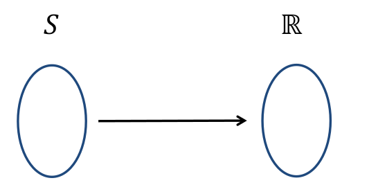

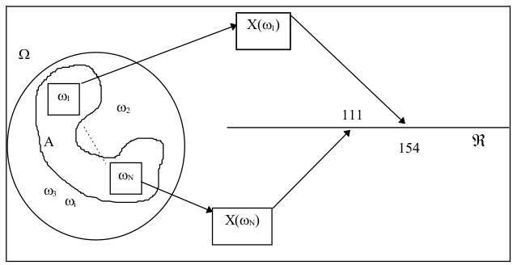

Algunos casos particulares de las variables aleatorias son:

- $[X \leq a]= {\omega \in \Omega: X(\omega) \leq a}$
- $[X = a]= {\omega \in \Omega: X(\omega) = a}$

**Ejemplo:** se realiza un experimento que consiste en lanzar tres monedas (no cargadas) al mismo tiempo. Si se define la variable aleatoria $X$ como el número de caras en cada lanzamiento, obtener:

- El espacio muestral
- Valor asociado a cada resultado

## Tipos de variables aleatorias

Las variables aleatorias pueden ser de dos tipos:

- **Discretas:** aquellas que sólo pueden tomar valores en un conjunto finito o infinito numerable.
- **Continuas:** aquellas que toman valores en uno o varios intervalos de la recta de los reales, en cuyo caso, el conjunto es no numerable.

# Distribución de una variable aleatoria discreta

Una variable aleatoria es un descriptor de eventos o sucesos aleatorios y su función de distribución asigna probabilidades a esos eventos.

## Función masa de probabilidad (f.m.a.)

La función masa de probabilidad (f.m.p) de una variable aleatoria discreta es un gráfico, tabla o fórmula que específica la probabilidad asociada a cada resultado del espacio muestral.
$$f(x)=P(X=x)$$

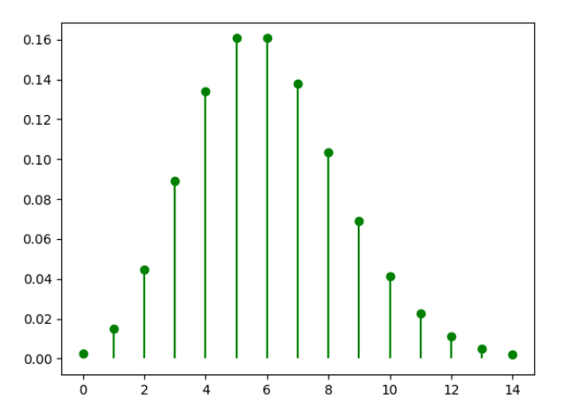

Para la f.m.p se satisfacen las siguientes condiciones o propiedades:

- $f(x_i) \geq 0$
- $\sum\nolimits_{i=1}^xf(x_i) = 1$
- $f(x_i) = P(X=x_i)$

## Función de distribución acumulada (f.d.a.)

Describe un evento particular, donde se asocia una probabilidad a los puntos muestrales de la variable aleatoria con un valor menor o igual que $x$.
$$f(x)=P(X \leq x) = \sum P(x_i); \ \forall\ x \in R$$

Para la f.d.a se satisfacen las siguientes condiciones:

- $f(a)=P(X \leq a) = \sum\nolimits_{x=-\infty}^a P(x)$
- $f(-\infty)=0$
- $f(\infty)=1$

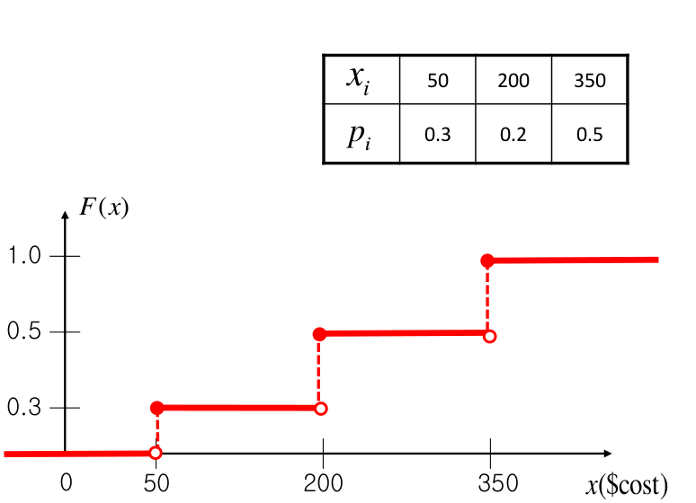

### Ejercicios

1. Suponga que la $f(x)$ representa una función de probabilidad dada por:
   $$f(x)=\frac{2x+1}{25}, x = 0, 1, 2, 3, 4$$

Hallar las siguientes probabilidades:

- $P(X = 4)$
- $P(X \leq 1)$
- $P(2 \leq X < 4)$
- $P(X > -10)$
2. Basado en el gráfico de la función de distribución acumulada, obtener las siguietnes probabilidades:
- $P(X=200)$
- $P(X \leq 200)$
- $P(X \geq 350)$

# Distribución de una variable aleatoria continua

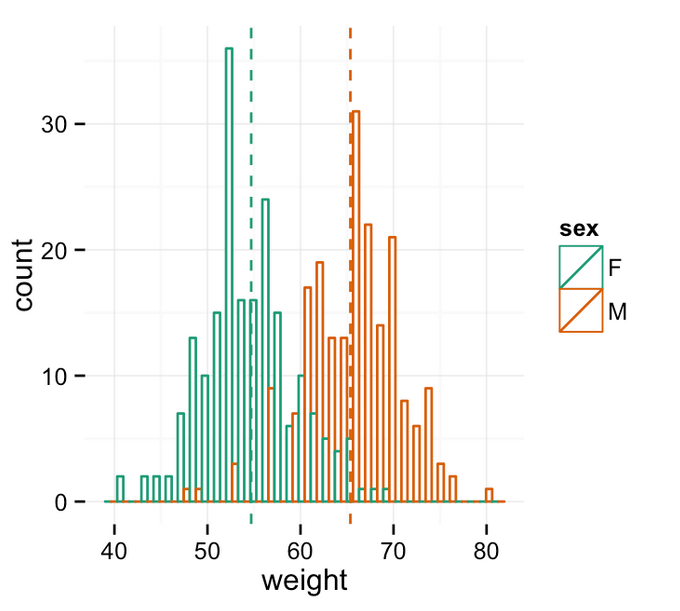

## Función de densidad

La función de densidad de probablidad $f(x)$ describe la distribución de probabilidad de una variable aleatoria continua.

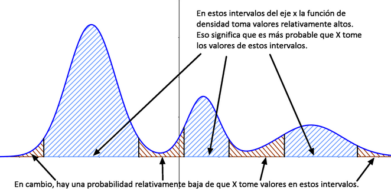

La probabilidad está determinada por el área bajo la curva desde un punto $a$ hasta el punto $b$.
$$P(a < X < b) =\ área\ bajo\ la\ curva$$

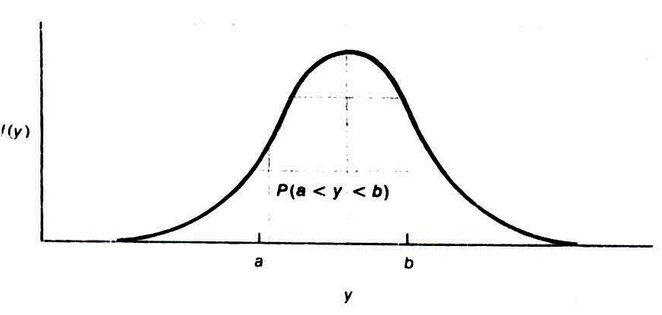

$$P(a < X < b) = \int_{a}^{b} f(x)dx; \ \forall\ a,b \in R$$

La función de densidad de una v.a. continua satisface las siguientes propiedaes:

- $f(x)>0$
- $\int_{-\infty}^{\infty} f(x) = 1$

## Función de distribución acumulada (f.d.a.)

De la definición de función de densidad de una variable aleatoria continua, se deduce que la función de distribución acumulada de esta variable puede ser obtenida a través de la siguiente expresión:
$$P(X \leq x) = \int_{-\infty}^{x} f(x)dx$$

# Medidas de resumen de una variable aleatoria

A cada variable aleatoria se asocia una función de distribución. El análisis del comportamiento de una variable se puede realizar mediante la descripción de su distribución, utilizando ciertos valores o parámetros que la caracterizan. En ese orden de ideas, si un experimento aleatorio es realizado y una variable aleatoria es definida, se puede determinar el valor esperado y la varianza de dicha variable aleatoria.

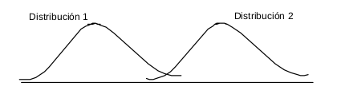

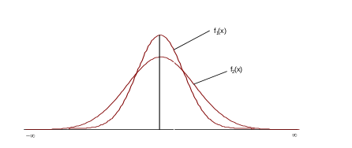

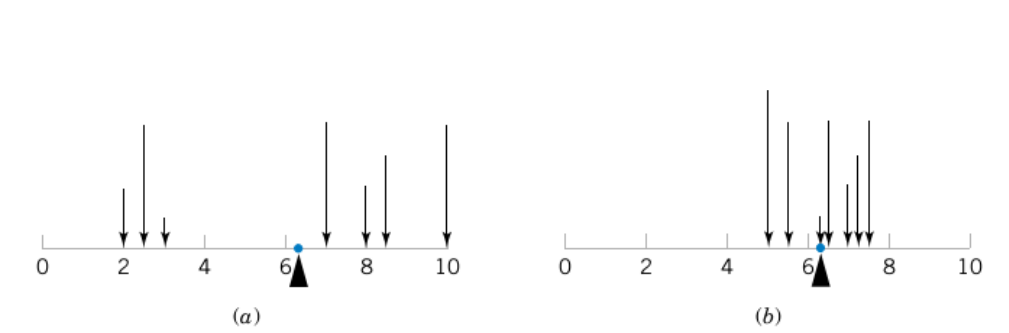

## Esperanza matemática - $E(X)$

La esperanza matemática de una variable aleatoria se puede definir desde un punto de vista intuitivo, como el promedio de los valores asumidos por la variable, donde cada valor es “ponderado” por su probabilidad de ocurrencia.

- **Esperanza matemática de una variable aleatoria discreta:**
  $$E(X) = \mu = \sum\nolimits_{i=1}^n x_if(x_i)$$
- **Esperanza matemática de una variable aleatoria continua:**
  $$E(X) = \mu = \int_{-\infty}^{\infty} xf(x)dx$$

**Nota:** esta integral no siempre existe, en cuyo caso, se dirá que la variable aleatoria no tiene esperanza matemática.

## Varianza - $Var(X)$

La esperanza matemática de una varible aleatoria sólo proporcona información parcial acerca de su distribución, indicando dónde está posicionada, sin embargo, dos o más distribuciones pueden tener la misma medida de posición y aún así, ser diferentes. Por ello surge la necesidad de una medida que indique similitud entre los valores de la variable aleatoria.

- **Varianza de una variable aleatoria discreta:**
  $$Var(X) = \sigma^2 = \sum\nolimits_{x_i}^n (x_i - \mu)^2 f(x_i)$$
- **Varianza de una variable aleatoria continua:**
  $$Var(X) = E[(x - \mu)^2] = \sigma^2 = \int_{-\infty}^{\infty} (x - \mu)^2 f(x) dx$$